# PRS training progress

Tianshu Liu

2024-06-20

## Stage 2 Analysis Plan

- **Train test split with ratio 8:2**
  - testing set not used in any stages of training (seed=1000)
- **10-fold cross validation split**
  - Split using simple random sampling, balanced sex and case proportions (seed=1000)
  - 11 GWAS-es (10 on the cv set and 1 on the big training set)
- **3 PRS methods**
  1. Pruning and Thresholding
  2. LDPred
  3. PRS-CSx

### Flowchart of data splitting

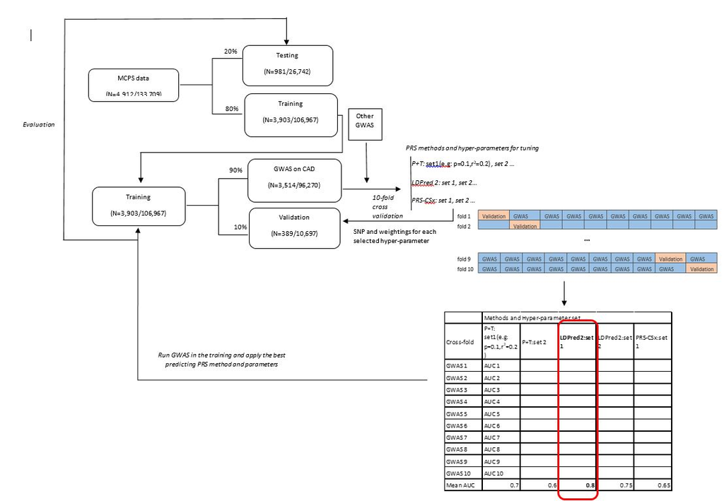

### Data split

- the case proportion is 3.7% for the whole MCPS data (people age 35-80)

```
##
##  CV data split proportion for fold 1                            control                  CAD_EPA
## training   92745(0.963384231847928) 3525(0.0366157681520723)
## validation 10319(0.964662989623259)  378(0.0353370103767411)
##
##  CV data split proportion for fold 2                            control                  CAD_EPA
## training   92771(0.963654305598837) 3499(0.0363456944011634)
## validation 10293(0.962232401607927)  404(0.0377675983920725)
##
##  CV data split proportion for fold 3                            control                  CAD_EPA
## training   92757(0.963508881271424) 3513(0.0364911187285759)
## validation 10307(0.963541179770029)   390(0.036458820229971)
##
##  CV data split proportion for fold 4                            control                  CAD_EPA
## training   92774(0.963685467954711) 3496(0.0363145320452893)
## validation  10290(0.96195194914462)    407(0.03804805085538)
##
##  CV data split proportion for fold 5                            control                  CAD_EPA
## training    92738(0.96330151343603) 3533(0.0366984865639705)
## validation 10326(0.965407629020195)  370(0.0345923709798055)
##
##  CV data split proportion for fold 6                            control                  CAD_EPA
## training   92733(0.963259582424431) 3537(0.0367404175755687)
## validation 10331(0.965784799476489)  366(0.0342152005235113)
##
##  CV data split proportion for fold 7                            control                  CAD_EPA
## training   92767(0.963602746413769) 3504(0.0363972535862305)
## validation 10297(0.962696335078534)   399(0.037303664921466)
##
##  CV data split proportion for fold 8                            control                  CAD_EPA
## training   92782(0.963758556574669) 3489(0.0362414434253306)
## validation 10282(0.961293941660434)  414(0.0387060583395662)
##
##  CV data split proportion for fold 9                            control                  CAD_EPA
## training   92757(0.963508881271424) 3513(0.0364911187285759)
## validation 10307(0.963541179770029)   390(0.036458820229971)
##
##  CV data split proportion for fold 10                            control                  CAD_EPA
## training   92752(0.963456944011634) 3518(0.0365430559883661)
## validation 10312(0.964008600542208)  385(0.0359913994577919)
```

### GWAS + Meta-analysis

- GWAS performed using Regenie
- Meta-analysed with case/control (overall N), for running P+T and LDPred:
  - **CKB (hg38)**: 13,748/62,107 (75,855)
  - **UKB (hg19)**: 34,541/261,984 (296,525)
  - **CC4D (hg19)**: 60,801/123,504 (184,305) – rough estimates
  - **BBJ (hg19)**: 25,892/142,336 (168,228)
- GWASes in hg19(GRCh37) genome build were lifted over to GRCh38 (as with MCPS) using **UCSC genome browser liftOver** tool and chain file.
- **Meta-analysis** using METAL (2020-05-05):
  1. UKB+CKB+MCPS
  2. UKB+CC4D+MCPS
  3. UKB+CC4D+BBJ+MCPS
  4. UKB+CKB+CC4D+BBJ+MCPS
  5. CC4D+BBJ+MCPS